# R Notebook

# Exercices on Swiss Cows data

## Part 1: Import the data

The data set of Swiss cows weights is in csv file swiss_cows_data.csv. Import the data in R using function readr::read_csv(), and then save it in a tibble that you will name cows.

```r
library(readr)
library(tibble)
library(dplyr)
library(tidyr)
library(janitor)
library(purrr)
library(stringr)
library(visdat)
#Sampling calcualtion
library(infer)
#For data visualisation
library(ggplot2)
```

The second step is the downloading and storing into a general value, the datasets.

```r
fitness_members_raw <- read_csv("data/fitness_members.csv")
fitness_tracking_raw <- read_csv("data/fitness_tracking.csv")
swiss_cows_raw <- read.csv("data/swiss_cows_data.csv", colClasses = c(
  num = "character"))
```

## Part 2: Perform a t-test using the first 3 cows of each breed

Do you remember the question of interest of Dr Heidi Lamucca ? Are Brown Swiss cows heavier than Swiss Red Holstein cows ?

In this part, you will focus on the first 3 cows of each breed, i.e. 6 cows in total. First create the cows_03 tibble as follows:

```r
cows_03 <- swiss_cows_raw %>%
  mutate(num = as.numeric(num)) %>%
  filter(num <= 3)
```

Before doing a t-test using cows_03 data, produce a summary table with sample size, arithmetic mean, and standard deviation for each breed of cattle.

Brown swiss sample size + arithmetic mean + standard deviation

Swiss red Holstein sample size + arithmetic mean + standard deviation

```r
swiss_cows_raw %>%
  group_by(breed) %>%
  summarise(
    number_cows = n(),
    mean_weight = mean(weight),
    sd_weight = sd(weight)
    )
```

| breed | number_cows | mean_weight | sd_weight |
| --- | --- | --- | --- |
| Brown_Swiss | 25 | 703.80 | 24.48129 |
| Swiss_Red_Holstein | 25 | 648.44 | 23.45044 |

Let’s comapre with our sample

```r
cows_03 %>%
  group_by(breed) %>%
  summarise(
    number_cows = n(),
    mean_weight = mean(weight),
    sd_weight = sd(weight)
    )
```

| breed | number_cows | mean_weight | sd_weight |
| --- | --- | --- | --- |
| Brown_Swiss | 3 | 688 | 28.16026 |
| Swiss_Red_Holstein | 3 | 659 | 28.58321 |

The t-test provides you with an objective tool to compare the two obtained means. With the {infer} package, you can perform the t-test as follows:

```r
my_test <- cows_03 %>%
  t_test(formula = weight ~ breed,
  order = c("Brown_Swiss", "Swiss_Red_Holstein"),
                              conf_level = 0.95)
```

In the above code, we saved the results of the t-test in my_test. Let’s have a look at its components:

```r
my_test
```

| statistic | t_df | p_value | alternative | estimate | lower_ci | upper_ci |
| --- | --- | --- | --- | --- | --- | --- |
| 1.251831 | 3.999111 | 0.2788521 | two.sided | 29 | -35.32495 | 93.32495 |

Let’s focus first on the last two elements: lower_ci and upper_ci. They correspond to the lower and upper limits of the 95% confidence interval (ci) for the difference between Brown Swiss average weight and Swiss Red Holstein average weight.

This interval contains the zero value. This means that the cows_03 data set does not provide enough evidence that Brown Swiss are heavier than Swiss Red Holstein.

This is also confirmed by the p-value of 0.279: having chosen a confidence level of 0.95, and the resulting p-value being higher than 0.05, we conclude that the difference between the two average weights is not statistically significant at the level of 0.05.

You can visualize the steps of the t-test process with the following code:

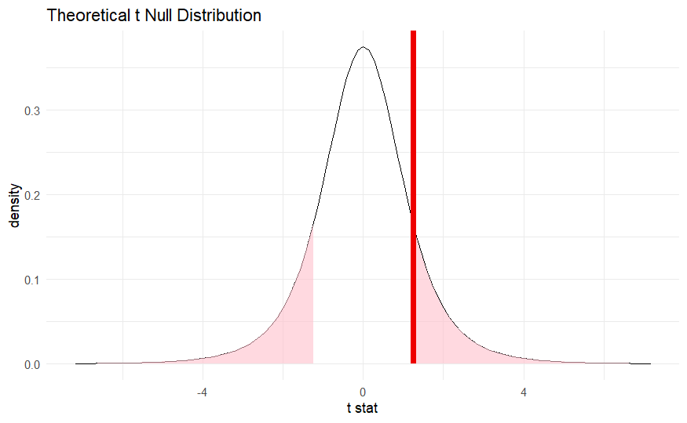

```r
t_obs <- my_test %>%
  select(statistic)

cows_03 %>%
  specify(formula = weight ~ breed) %>%
  hypothesize(null = 'independence') %>%
  calculate(stat = "t") %>%
  visualise(method = "theoretical") +
  shade_p_value(obs_stat = t_obs, direction = "both") +
  theme_minimal()
```

In the above code, the observed t-statistic is saved first in t_obs. This value is used in the subsequent block to visualize the p-value. The verbs specify, hypothesize, calculate and visualise correspond to basic {infer} actions to perform statistical tests. The function shade_p_value is then used to visualise the resulting p-value in the graphical output.

In the resulting graph, the area under the density curve is equal to 1. What is the area of the red region under this density curve ?

## Part 3: Perform a t-test using only the first cow of each breed

Create tibble cows_01 with only one cow from each breed, i.e. 2 cows in total. Perform the t-test on this data set using the t_test function like you did with cows_03 data.

What results do you obtain ? Try to explain what is going on here.

```r
cows_01 <- swiss_cows_raw %>%
  mutate(num = as.numeric(num)) %>%
  filter(num <= 1)

my_test01 <- cows_01 %>%
  t_test(formula = weight ~ breed,
  order = c("Brown_Swiss", "Swiss_Red_Holstein"),
                              conf_level = 0.95)
```

```
Erreur dans t.test.default(x = DATA[[1L]], y = DATA[[2L]], ...) :
  nombre d'observations 'x' insuffisant
```

I got an error: “Erreur dans t.test.default(x = DATA[[1L]], y = DATA[[2L]], …) : nombre d’observations ‘x’ insuffisant” This error occurs because I don’t have enough data to do calculate a mean.

## Part 4: Perform a t-test using all the cows of each breed

Perform the t-test on the whole cows data set using the t_test function. Produce as well the density graph showing the resulting p-value of the t-test.

What are the lower and upper limits of the 95% confidence interval for the difference between the average weight of Brown Swiss and the average weight of Red Swiss Holstein ?

```r
my_test_allcows <- swiss_cows_raw %>%
  t_test(formula = weight ~ breed,
  order = c("Brown_Swiss", "Swiss_Red_Holstein"),
                              conf_level = 0.95)

my_test_allcows
```

| statistic | t_df | p_value | alternative | estimate | lower_ci | upper_ci |
| --- | --- | --- | --- | --- | --- | --- |
| 8.165026 | 47.91144 | 1.258282e-10 | two.sided | 55.36 | 41.72697 | 68.99303 |

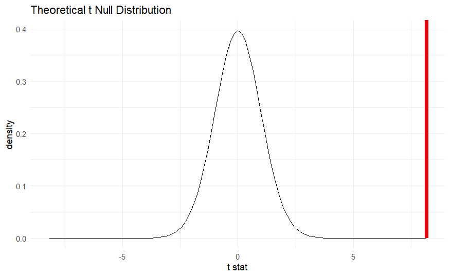

```r
t_obs <- my_test_allcows %>%
  select(statistic)

swiss_cows_raw %>%
  specify(formula = weight ~ breed) %>%
  hypothesize(null = 'independence') %>%
  calculate(stat = "t") %>%
  visualise(method = "theoretical") +
  shade_p_value(obs_stat = t_obs, direction = "both") +
  theme_minimal()
```

Right answer ! This confidence interval does not contain the zero value. The cows data set provides therefore enough evidence that Brown Swiss are heavier than Swiss Red Holstein.

Is the p-value greater or lower than 0.05 ? Write in your report the conclusion that you get from the t-test. Use the words difference and statistically significant.

The p-value is 1.258282e-10, which means ~0.0000000001258282, so really lower than 0.05. The fact that the p value is lower than 0.05 means we can reject the null hypothesis and that the test is statistically significant at 99%. It means that the weight between the two breeds of cows is significantly different.

# Exercices on Fitness Club data

## Part 5: Import the data

Already done.

## Part 6: t-test

Let’s try to see with the data if there is an evolution of bmi.

First, let’s create a table with the BMI as value.

```r
# Only get wk_000
week_one_tibble <- fitness_members_raw %>%
  mutate(wk_000 = weight) %>%
  select(id,m_category,height,wk_000)

colnames_fitness_tracker <- colnames(fitness_tracking_raw)
# Let's just remove the id column from this vector
colnames_fitness_tracker <- colnames_fitness_tracker[!colnames_fitness_tracker == 'id']
colnames_fitness_tracker <- append(colnames_fitness_tracker, 'wk_000')

# List of dfs to join them
list_df <- list(week_one_tibble, fitness_tracking_raw)

# Join both tibbles
fitness_tracking_with_wk_000 <- list_df %>%
  reduce(left_join, by='id')

# Now we can pivot longer
fitness_tracking_long <- fitness_tracking_with_wk_000 %>%
  pivot_longer(cols = all_of(colnames_fitness_tracker), names_to = "week_nb", values_to = "weight") %>%
  drop_na()

calculate_bmi <- function(w,h){
  w / (h/100)^2
}

fitness_tracking_long <- fitness_tracking_long %>%
  group_by(id) %>%
  mutate(bmi = calculate_bmi(weight,height)) %>%
  mutate_if(is.numeric,
            round,
            digits = 1)
```

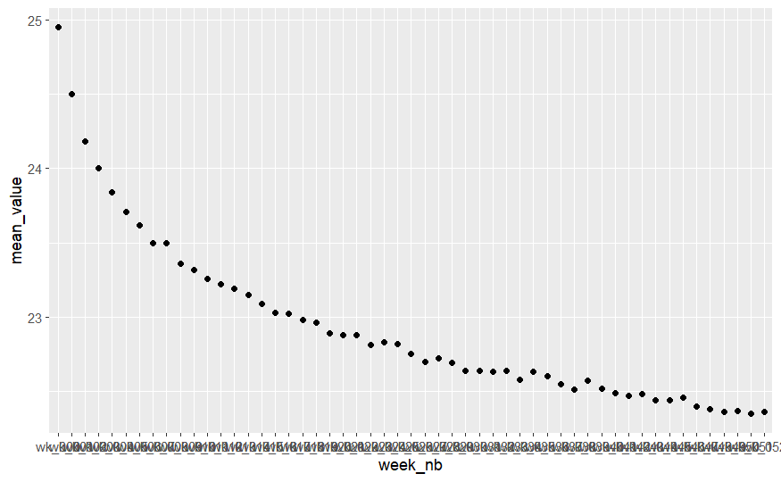

```r
fitness_tracking_long_head_10 <- fitness_tracking_long %>%
  select(id,week_nb,bmi)%>%
  group_by(id) %>%
  pivot_wider(
    names_from = week_nb,
    values_from = bmi
  ) %>%
  relocate(wk_000) %>%
  relocate(id) %>%
  head(10)

#Creation of a tibble which shows the means of the bmi for each week
weekly_means_for_head_10 <- tibble(
  colnames(fitness_tracking_long_head_10),
  map_dbl(fitness_tracking_long_head_10, mean)
  ) %>%
  rename(week_nb = 1,
         mean_value = 2) %>%
  slice(-1)
ggplot(data=weekly_means_for_head_10, aes(x=week_nb, y=mean_value)) +
  geom_point()
```

As we can see in the chart above, the mean value of the bmi of the 10 first people in the fitness database decreased after 52 weeks.

Do we observe a different evolution of BMI from week 0 to week 12 in the different fitness club membership categories ?

```r
calculate_bmi <- function(w,h){
  w / (h/100)^2
}

calculate_mean_bmi_of_a_week <- function(h, w, c){

  (sum(w,na.rm = TRUE)/c)/((sum(h)/c)/100)^2
}

weeks_to_12 <- c("wk_000","wk_001","wk_002","wk_003","wk_004","wk_005","wk_006","wk_007","wk_008","wk_009","wk_010","wk_011","wk_012")

fitness_tracking_means_by_week_to_12 <- fitness_tracking_with_wk_000 %>%
  select(id,m_category,height,numerical_cols_fitness_tracking_12) %>%
  group_by(m_category) %>%
  mutate(count_cat = n()) %>%
  mutate(wk_000 = calculate_mean_bmi_of_a_week(height,wk_000,count_cat)) %>%
  mutate(wk_001 = calculate_mean_bmi_of_a_week(height,wk_001,count_cat)) %>%
  mutate(wk_002 = calculate_mean_bmi_of_a_week(height,wk_002,count_cat)) %>%
  mutate(wk_003 = calculate_mean_bmi_of_a_week(height,wk_003,count_cat)) %>%
  mutate(wk_004 = calculate_mean_bmi_of_a_week(height,wk_004,count_cat)) %>%
  mutate(wk_005 = calculate_mean_bmi_of_a_week(height,wk_005,count_cat)) %>%
  mutate(wk_006 = calculate_mean_bmi_of_a_week(height,wk_006,count_cat)) %>%
  mutate(wk_007 = calculate_mean_bmi_of_a_week(height,wk_007,count_cat)) %>%
  mutate(wk_008 = calculate_mean_bmi_of_a_week(height,wk_008,count_cat)) %>%
  mutate(wk_009 = calculate_mean_bmi_of_a_week(height,wk_009,count_cat)) %>%
  mutate(wk_010 = calculate_mean_bmi_of_a_week(height,wk_010,count_cat)) %>%
  mutate(wk_011 = calculate_mean_bmi_of_a_week(height,wk_011,count_cat)) %>%
  mutate(wk_012 = calculate_mean_bmi_of_a_week(height,wk_012,count_cat)) %>%
  distinct(m_category, .keep_all = TRUE) %>%
  select(-1, -3) %>%
  mutate_if(is.numeric,
            round,
            digits = 1) %>%
  pivot_longer(
    cols = weeks_to_12,
    names_to = "week_nb",
    values_to = "mean_bmi"
    ) %>%
  select(-2) %>%
  ungroup()
```

[output not shown]

Now we have data a bit better prepared, we can do the t_test.

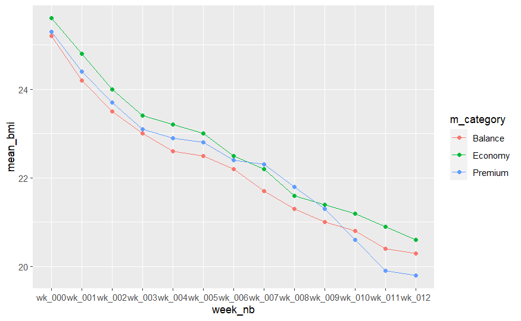

```r
ggplot(fitness_tracking_means_by_week_to_12, aes(x=week_nb, y=mean_bmi, group=m_category)) +
  geom_line(aes(color=m_category))+
  geom_point(aes(color=m_category))
```

The line chart above show use how the 3 mean bmi evoluate depending on the category. And the t_test:

```r
fitness_tracking_means_by_week_to_12 %>%
  t_test(formula = mean_bmi ~ m_category,
  order = c("Economy", "Premium"),
                              conf_level = 0.95)
```

| statistic | t_df | p_value | alternative | estimate | lower_ci | upper_ci |
| --- | --- | --- | --- | --- | --- | --- |
| 0.5036967 | 23.87779 | 0.6190902 | two.sided | 0.3153846 | -0.9772549 | 1.608024 |

## Chi-squared test

The chi-squared test can be used to perform an inferential analysis on this data. Before doing it, execute the following code:

```r
fitness_members <-  fitness_members_raw %>%
  mutate(m_category = factor(m_category, levels = c("Economy", "Balance", "Premium")))

fitness_members
```

[output not shown]

Use chisq_test() function of {infer} package. The first argument required by this function is data, i.e. fitness_members in this case. The second argument is formula to be specified with the same format as for t_test() that you used in Part 2, i.e. with the format factor_1 ~ factor_2.

```r
chisq_test_fitness_members <- fitness_members %>%
  chisq_test(
    formula = gender ~ m_category
  )
chisq_test_fitness_members
```

[output not shown]

## Part 8: Visualise p-value

Use specify, hypothesize, calculate, visualise and shade_p_value functions of {infer} package to visualise the p-value that you obtained with chisq_test().

```r
fitness_members %>%
    specify(
      formula = gender ~ m_category,
      ) %>%
  hypothesize(null = "independence") %>%
  assume(distribution = "Chisq") %>%
  visualize()+
  shade_p_value(obs_stat = chisq_test_fitness_members, direction = "greater") +
  theme_minimal()
```

[output not shown]